# HEART DISEASE ANALYSIS

Aryan Khokhar

2023-06-28

## INTRODUCTION

This dataset is about heart disease. The dataset used for this analysis can be downloaded from https://www.kaggle.com/datasets/johnsmith88/heart-disease-dataset.

Before beginning, let me first lay the roadmap for this analysis. So, I’ll perform the following tasks on this dataset:  
* Cleaning the data (if needed)  
* Transforming the data OR Data Manipulation  
* Analysis  
* Conclusion

Starting with installing few packages and loading the dataset and also removing all the previously stored variables.

```r
rm(list=ls()) #Removes all previously stored variables
```

```r
library(tidyverse)
data <- read.csv("heart.csv")
view(data)
```

The dataset has 14 variables(columns) and 1025 observations(rows). Here we can use few other functions to get a brief summary about the data.

Here is the name of the columns and the explanation of each variable as described in Kaggle.

1. age: The age of a person
2. sex: The person’s gender(1 = male, 0 = female)
3. cp: The types of chest pain experienced (Value 1: typical angina, Value 2: atypical angina, Value 3: non-anginal pain, Value 4: asymptomatic)
4. trestbps: Resting blood pressure (mm Hg on admission to the hospital)
5. chol: Cholesterol measurement in mg/dl
6. fbs: Fasting blood sugar (if > 120 mg/dl, 1 = true; 0 = false)
7. restecg: Resting electrocardiographic measurement (0 = normal, 1 = having ST-T wave abnormality, 2 = showing probable or definite left ventricular hypertrophy by Estes’ criteria)
8. thalach: Maximum heart rate achieved
9. exang: Exercise induced angina (1 = yes; 0 = no)
10. oldpeak: ST depression induced by exercise relative to rest (‘ST’ relates to positions on the ECG plot)
11. slope: the slope of the peak exercise ST segment (Value 1: upsloping, Value 2: flat, Value 3: downsloping)
12. ca: The number of major vessels (0–3)
13. thal: A blood disorder called thalassemia (1 = normal; 2 = fixed defect; 3 = reversable defect)
14. target: Heart disease (0 = no, 1 = yes)

```r
head(data) #Shows first 6 rows of the data
```

```
##   age sex cp trestbps chol fbs restecg thalach exang oldpeak slope ca thal
## 1  52   1  0      125  212   0       1     168     0     1.0     2  2    3
## 2  53   1  0      140  203   1       0     155     1     3.1     0  0    3
## 3  70   1  0      145  174   0       1     125     1     2.6     0  0    3
## 4  61   1  0      148  203   0       1     161     0     0.0     2  1    3
## 5  62   0  0      138  294   1       1     106     0     1.9     1  3    2
## 6  58   0  0      100  248   0       0     122     0     1.0     1  0    2
##   target
## 1      0
## 2      0
## 3      0
## 4      0
## 5      0
## 6      1
```

```r
tail(data) #Shows last 6 rows of the data
```

```
##      age sex cp trestbps chol fbs restecg thalach exang oldpeak slope ca thal
## 1020  47   1  0      112  204   0       1     143     0     0.1     2  0    2
## 1021  59   1  1      140  221   0       1     164     1     0.0     2  0    2
## 1022  60   1  0      125  258   0       0     141     1     2.8     1  1    3
## 1023  47   1  0      110  275   0       0     118     1     1.0     1  1    2
## 1024  50   0  0      110  254   0       0     159     0     0.0     2  0    2
## 1025  54   1  0      120  188   0       1     113     0     1.4     1  1    3
##      target
## 1020      1
## 1021      1
## 1022      0
## 1023      0
## 1024      1
## 1025      0
```

```r
glimpse(data)
```

```
## Rows: 1,025
## Columns: 14
## $ age      <int> 52, 53, 70, 61, 62, 58, 58, 55, 46, 54, 71, 43, 34, 51, 52, 3…
## $ sex      <int> 1, 1, 1, 1, 0, 0, 1, 1, 1, 1, 0, 0, 0, 1, 1, 0, 0, 1, 0, 1, 1…
## $ cp       <int> 0, 0, 0, 0, 0, 0, 0, 0, 0, 0, 0, 0, 1, 0, 0, 1, 2, 0, 1, 2, 2…
## $ trestbps <int> 125, 140, 145, 148, 138, 100, 114, 160, 120, 122, 112, 132, 1…
## $ chol     <int> 212, 203, 174, 203, 294, 248, 318, 289, 249, 286, 149, 341, 2…
## $ fbs      <int> 0, 1, 0, 0, 1, 0, 0, 0, 0, 0, 0, 1, 0, 0, 1, 0, 0, 0, 0, 1, 0…
## $ restecg  <int> 1, 0, 1, 1, 1, 0, 2, 0, 0, 0, 1, 0, 1, 1, 1, 1, 0, 0, 1, 0, 0…
## $ thalach  <int> 168, 155, 125, 161, 106, 122, 140, 145, 144, 116, 125, 136, 1…
## $ exang    <int> 0, 1, 1, 0, 0, 0, 0, 1, 0, 1, 0, 1, 0, 1, 1, 0, 0, 1, 0, 0, 0…
## $ oldpeak  <dbl> 1.0, 3.1, 2.6, 0.0, 1.9, 1.0, 4.4, 0.8, 0.8, 3.2, 1.6, 3.0, 0…
## $ slope    <int> 2, 0, 0, 2, 1, 1, 0, 1, 2, 1, 1, 1, 2, 1, 1, 2, 2, 1, 2, 2, 1…
## $ ca       <int> 2, 0, 0, 1, 3, 0, 3, 1, 0, 2, 0, 0, 0, 3, 0, 0, 1, 1, 0, 0, 0…
## $ thal     <int> 3, 3, 3, 3, 2, 2, 1, 3, 3, 2, 2, 3, 2, 3, 0, 2, 2, 3, 2, 2, 2…
## $ target   <int> 0, 0, 0, 0, 0, 1, 0, 0, 0, 0, 1, 0, 1, 0, 0, 1, 1, 0, 1, 1, 0…
```

```r
summary(data) #Statistical overview of the data
```

```
##       age             sex               cp            trestbps
##  Min.   :29.00   Min.   :0.0000   Min.   :0.0000   Min.   : 94.0
##  1st Qu.:48.00   1st Qu.:0.0000   1st Qu.:0.0000   1st Qu.:120.0
##  Median :56.00   Median :1.0000   Median :1.0000   Median :130.0
##  Mean   :54.43   Mean   :0.6956   Mean   :0.9424   Mean   :131.6
##  3rd Qu.:61.00   3rd Qu.:1.0000   3rd Qu.:2.0000   3rd Qu.:140.0
##  Max.   :77.00   Max.   :1.0000   Max.   :3.0000   Max.   :200.0
##       chol          fbs            restecg          thalach
##  Min.   :126   Min.   :0.0000   Min.   :0.0000   Min.   : 71.0
##  1st Qu.:211   1st Qu.:0.0000   1st Qu.:0.0000   1st Qu.:132.0
##  Median :240   Median :0.0000   Median :1.0000   Median :152.0
##  Mean   :246   Mean   :0.1493   Mean   :0.5298   Mean   :149.1
##  3rd Qu.:275   3rd Qu.:0.0000   3rd Qu.:1.0000   3rd Qu.:166.0
##  Max.   :564   Max.   :1.0000   Max.   :2.0000   Max.   :202.0
##      exang           oldpeak          slope             ca
##  Min.   :0.0000   Min.   :0.000   Min.   :0.000   Min.   :0.0000
##  1st Qu.:0.0000   1st Qu.:0.000   1st Qu.:1.000   1st Qu.:0.0000
##  Median :0.0000   Median :0.800   Median :1.000   Median :0.0000
##  Mean   :0.3366   Mean   :1.072   Mean   :1.385   Mean   :0.7541
##  3rd Qu.:1.0000   3rd Qu.:1.800   3rd Qu.:2.000   3rd Qu.:1.0000
##  Max.   :1.0000   Max.   :6.200   Max.   :2.000   Max.   :4.0000
##       thal           target
##  Min.   :0.000   Min.   :0.0000
##  1st Qu.:2.000   1st Qu.:0.0000
##  Median :2.000   Median :1.0000
##  Mean   :2.324   Mean   :0.5132
##  3rd Qu.:3.000   3rd Qu.:1.0000
##  Max.   :3.000   Max.   :1.0000
```

## DATA TRANSFORMATION

There are a lot of things that can be done with a dataset like this. Also, it can be analyzed in so many different ways. So many different plots and tables can be generated to explain in different ways.

To begin with, it will be helpful if we transform our data in another table and extract and focus on those variables only which are more important.

So, we’ll make changes in “target,sex,fbs,exang,cp,restecg,slope,ca,thal” variables and leave the rest as it is.

```r
data2 <- data %>%
  mutate(sex = if_else(sex == 1, "MALE", "FEMALE"),
         fbs = if_else(fbs == 1, ">120", "<=120"),
         exang = if_else(exang == 1, "YES", "NO"),
         cp = if_else(cp == 0, "TYPICAL ANGINA",
                      if_else(cp == 1,"ATYPICAL ANGINA",
                       if_else(cp == 2, "NON-ANGINAL PAIN", "ASYMPTOMATIC"))),
         restecg = if_else(restecg == 0, "NORMAL",
                            if_else(restecg == 1, "ABNORMALITY", "PROBALBLE OR DEFINITE")),
         slope = as.factor(slope),
         ca = as.factor(ca),
         thal = as.factor(thal),
         target = if_else(target == 1, "YES", "NO")
         ) %>%
  mutate_if(is.character,as.factor) %>%
  dplyr::select(target,sex,fbs,exang,cp,restecg,slope,ca,thal,everything())

view(data2)
glimpse(data2)
```

```
## Rows: 1,025
## Columns: 14
## $ target   <fct> NO, NO, NO, NO, NO, YES, NO, NO, NO, NO, YES, NO, YES, NO, NO…
## $ sex      <fct> MALE, MALE, MALE, MALE, FEMALE, FEMALE, MALE, MALE, MALE, MAL…
## $ fbs      <fct> <=120, >120, <=120, <=120, >120, <=120, <=120, <=120, <=120, …
## $ exang    <fct> NO, YES, YES, NO, NO, NO, NO, YES, NO, YES, NO, YES, NO, YES,…
## $ cp       <fct> TYPICAL ANGINA, TYPICAL ANGINA, TYPICAL ANGINA, TYPICAL ANGIN…
## $ restecg  <fct> ABNORMALITY, NORMAL, ABNORMALITY, ABNORMALITY, ABNORMALITY, N…
## $ slope    <fct> 2, 0, 0, 2, 1, 1, 0, 1, 2, 1, 1, 1, 2, 1, 1, 2, 2, 1, 2, 2, 1…
## $ ca       <fct> 2, 0, 0, 1, 3, 0, 3, 1, 0, 2, 0, 0, 0, 3, 0, 0, 1, 1, 0, 0, 0…
## $ thal     <fct> 3, 3, 3, 3, 2, 2, 1, 3, 3, 2, 2, 3, 2, 3, 0, 2, 2, 3, 2, 2, 2…
## $ age      <int> 52, 53, 70, 61, 62, 58, 58, 55, 46, 54, 71, 43, 34, 51, 52, 3…
## $ trestbps <int> 125, 140, 145, 148, 138, 100, 114, 160, 120, 122, 112, 132, 1…
## $ chol     <int> 212, 203, 174, 203, 294, 248, 318, 289, 249, 286, 149, 341, 2…
## $ thalach  <int> 168, 155, 125, 161, 106, 122, 140, 145, 144, 116, 125, 136, 1…
## $ oldpeak  <dbl> 1.0, 3.1, 2.6, 0.0, 1.9, 1.0, 4.4, 0.8, 0.8, 3.2, 1.6, 3.0, 0…
```

The transformed data is ready. Let’s dive into data visualisation.

## ANALYSIS

We will start with a simple bar graph depicting the presence and absence of heart disease in individuals. We’ll count how many individuals are suffering from heart disease and how many are not.

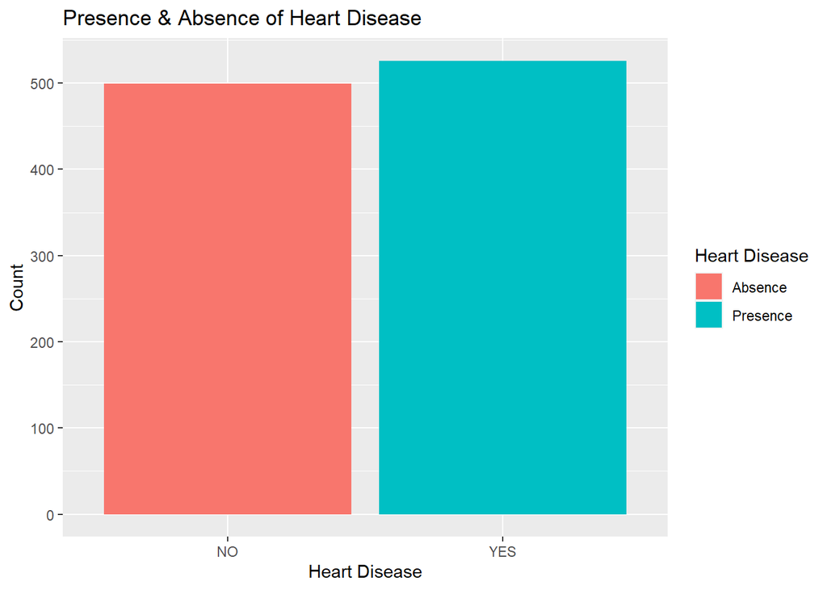

```r
ggplot(data2, aes(x=data2$target, fill=data2$target))+
  geom_bar()+
  xlab("Heart Disease")+
  ylab("Count")+
  ggtitle("Presence & Absence of Heart Disease")+
  scale_fill_discrete(name="Heart Disease", labels=c("Absence","Presence"))
```

We can also show this result in percentage of individuals having and not having heart disease.

```r
round(prop.table(table(data2$target)),2) #To check the %age
```

```
##
##   NO  YES
## 0.49 0.51
```

Now moving forward we want to see how the number of patients are distributed in different age groups and to check that first we’ll form the ‘age_grp’ column using our original data. This is because here we want the sum of ‘target’ column and since, in transformed data ‘target’ column is factor variable that is why we are using the original data in which ‘target’ is an integer variable.

```r
data$age_grp <- cut(data$age, breaks=seq(25, 77, 4))

target_by_age <- data %>%
                  group_by(age_grp) %>%
                  summarise(heart_patients = sum(target))
target_by_age
```

```
## # A tibble: 12 × 2
##    age_grp heart_patients
##    <fct>            <int>
##  1 (25,29]              4
##  2 (33,37]             20
##  3 (37,41]             50
##  4 (41,45]             82
##  5 (45,49]             43
##  6 (49,53]             87
##  7 (53,57]             80
##  8 (57,61]             52
##  9 (61,65]             53
## 10 (65,69]             35
## 11 (69,73]             14
## 12 (73,77]              6
```

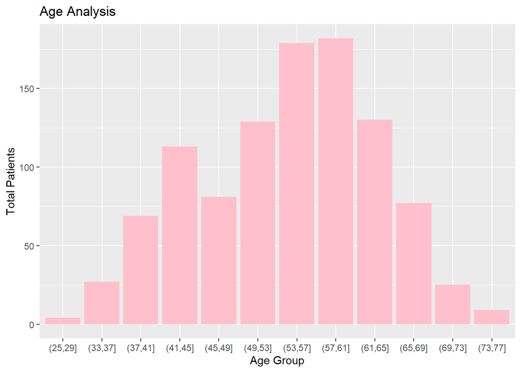

```r
data %>%
  group_by(age_grp) %>%
  count() %>%
  ggplot()+
  geom_col(aes(x=age_grp, y=n), fill='pink')+
  ggtitle("Age Analysis")+
  xlab("Age Group")+
  ylab("Total Patients")
```

Further we can form a contingency table showing proportion of males and females suffering from heart disease or not.

```r
round(prop.table(table(data2$sex, data2$target)), 2)
```

```
##
##            NO  YES
##   FEMALE 0.08 0.22
##   MALE   0.40 0.29
```

We can also compare the blood pressure in male and female patients, further comparing the results for different kinds of chest pain using a boxplot.

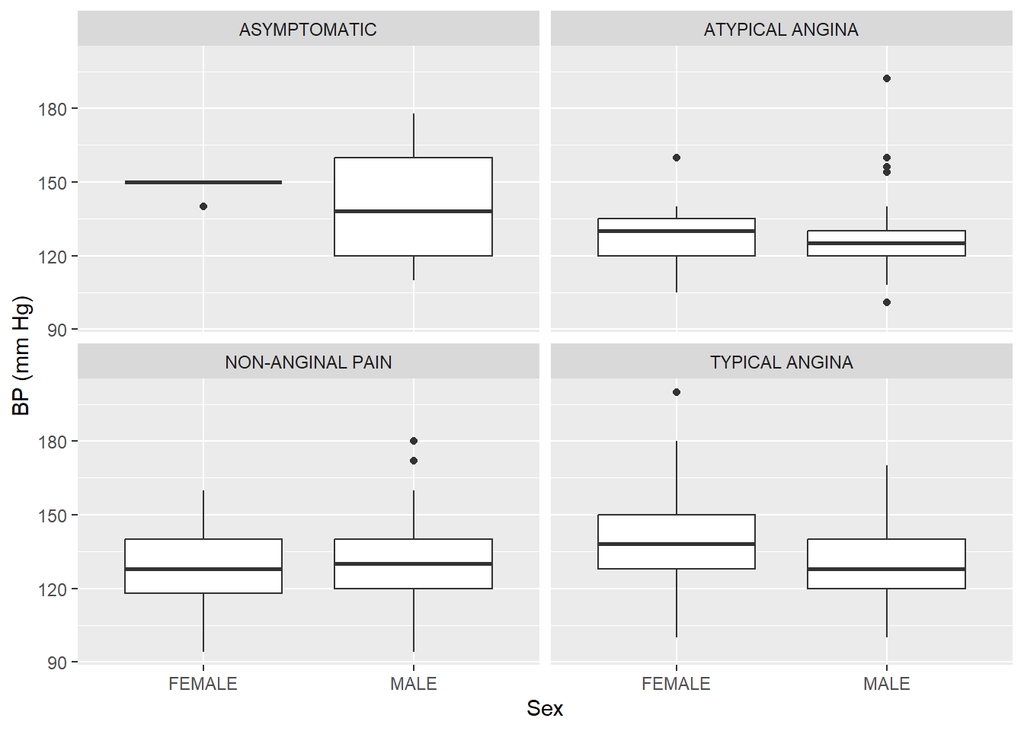

```r
data2 %>%
  ggplot(aes(x=sex, y=trestbps))+
  geom_boxplot()+
  xlab("Sex")+
  ylab("BP (mm Hg)")+
  facet_wrap(~cp)
```

Again let us make another boxplot and now compare the cholesterol level on male and female and grouped by chest pain.

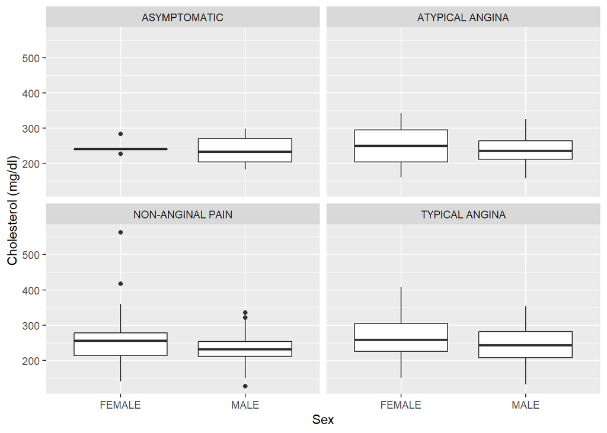

```r
data2 %>%
  ggplot(aes(x=sex, y=chol))+
  geom_boxplot()+
  xlab("Sex")+
  ylab("Cholesterol (mg/dl)")+
  facet_wrap(~cp)
```

It will be great if we could see how the variables are correlated with each other. For that we must install and load the “corrplot” package as well as the “ggplot2” package.

```r
#install.packages("corrplot")
library(corrplot)
library(ggplot2)
```

We’ll start by finding out the correlation among last 5 columns of our dataset “data2” then finally showcasing it using corrplot() function.

```r
cor_heart <- round(cor(data2[,10:14]),2)
cor_heart
```

```
##            age trestbps  chol thalach oldpeak
## age       1.00     0.27  0.22   -0.39    0.21
## trestbps  0.27     1.00  0.13   -0.04    0.19
## chol      0.22     0.13  1.00   -0.02    0.06
## thalach  -0.39    -0.04 -0.02    1.00   -0.35
## oldpeak   0.21     0.19  0.06   -0.35    1.00
```

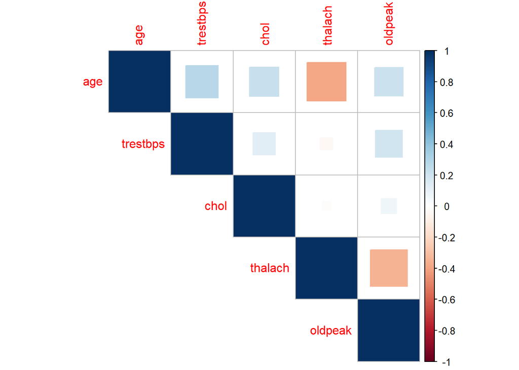

```r
corrplot(cor_heart, method = "square", type = "upper")
```